# Combining spatial transcriptomics, pseudotime and machine learning to find biomarkers for prostate cancer

## Abstract

Early cancer diagnosis is crucial but challenging due to a lack of reliable biomarkers that can be measured with routine clinical methods. Identification of such biomarkers is complicated by each tumor involving changed interactions between thousands of genes. On top of this staggering complexity, those interactions can vary among patients with the same diagnosis, as well as within the same tumor. We hypothesized that reliable biomarkers that can be measured with routine methods could be identified by exploiting three facts: (1) The same tumor can have multiple grades of malignant transformation; (2) these grades, and their molecular changes, can be characterized using spatial transcriptomics; and (3) those changes can be integrated into models of malignant transformation using pseudotime. We constructed such pseudotime models based on spatial transcriptomics data from three independent prostate cancer studies, to prioritize the genes most correlated with malignant transformation. In support of the relevance of those genes, they were associated with cancer grade, copy number aberrations, cancer hallmark pathways and drug targets. We therefore hypothesized that these genes would encode candidate biomarkers for prostate cancer. Our hypothesis was supported by analyses of mRNA, immunohistochemistry and proteomics data from sera, prostate tissue and urine from more than 2000 patients with prostate cancer and controls.

Using machine learning we demonstrated that prediction models based on the protein levels of the candidate biomarkers in urine had an AUC of 0.94 for prostate cancer, and that these proteins were associated with cancer grade. To our knowledge, combining spatial transcriptomics, pseudotime and machine learning is a novel approach to systematically identify biomarkers. We propose prospective studies to test the diagnostic potential of the biomarkers in prostate cancer, as well as the analytical strategy in other cancers.

Significance: Combining spatial transcriptomics, pseudotime and machine learning provides an effective approach to find biomarkers for prostate cancer

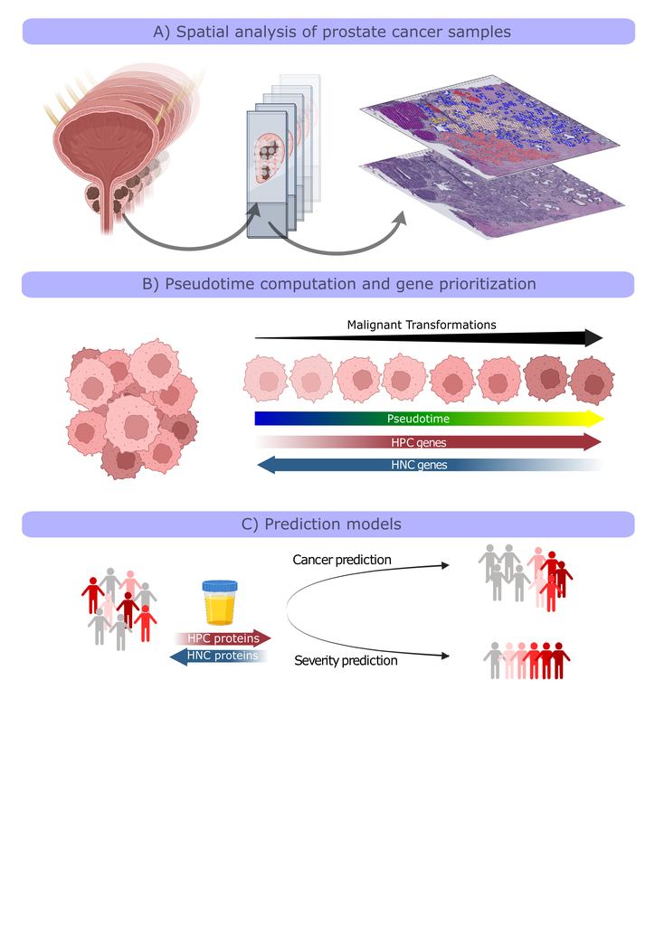

Overview figure.